# Spotify music trends analysis

Maksymilian Hala

2026-04-17

## 1. Defining the Problem

The goal of this project is to analyze the evolution of music hits on Spotify between 1970 and 2024.

The primary objective that came up during the analysis is to investigate the steady decline in average “energy” levels in the 2010s and determine if the rise of specific genres like hip-hop or pop has influenced this trend.

### Key Research Questions:

- How has the mean energy of top hits changed over the decades?
  - What determined the energy decline in the 2010s?
  - How does popularity of leading mainstream genres affect this sudden change?
- How has song duration evolved across mainstream music?

## 2. Data Sourcing

The data for this analysis was sourced from the kaggle **Spotify Hits Dataset**, which contained data of billboard 200 hits from 1960s to 2020s (The analysis covered tracks from 1970s, as data before that time was mostly incomplete)

This dataset is reliable as it contains verified audio features (energy, valence, tempo) extracted directly via the Spotify Web API.

## 3. Process: Data Cleaning and Transformation

To ensure data integrity, a two-step cleaning process was implemented using **SQL (BigQuery)** and **R**.

```sql
SELECT DISTINCT

--Here I prepared a few interesting audio features and other categories needed for my analysis

  `Track URI` AS track_uri,
  LOWER(TRIM(`Track Name`)) AS track_name,
  LOWER(TRIM(`Artist Name_s_`)) AS artist_name,
  CAST(LEFT(`Album Release Date`, 4) AS INT64) AS release_year,
  `Explicit` AS explicit,
  `Danceability` AS danceability,
  `Energy` AS energy,
  `Speechiness` AS speechiness,
  `Acousticness` AS acousticness,
  `Liveness` AS liveness,
  `Valence` AS valence,
  `Tempo` AS tempo,
  ROUND(`Track Duration _ms_` / 1000, 2) AS track_duration_s,
  LOWER(TRIM(`Artist Genres`)) AS genres

FROM
  `spotify-hits-490117.spotify.hits`

WHERE
  `Track Name` IS NOT NULL
  AND TRIM(`Track Name`) != ''
  AND `Artist Name_s_` IS NOT NULL
  AND TRIM(`Artist Name_s_`) != ''
  AND `Album Release Date` IS NOT NULL
  AND TRIM(`Album Release Date`) != ''

--It`s worth mentioning that I didnt use every one of these features,
--but they are left for possible further analysis
```

After cleaning the dataset in SQL, the rest of the analysis was conducted in R.

## 4. Data Analysis

### Question 1:

How has the mean energy of top hits changed over the decades?

```r
library(patchwork)
library(tidyverse)
```

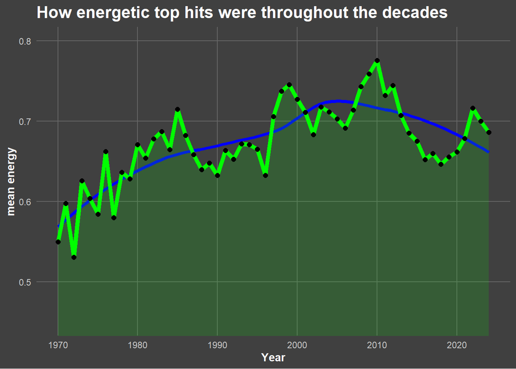

```r
music_trends_v2 <- music_data_v2 %>%
  filter(release_year >=1970) %>%
  group_by(release_year) %>%
  summarise(avg_energy = mean(energy, na.rm = TRUE))

energy_plot <- ggplot(data = music_trends_v2, aes(x = release_year, y = avg_energy)) +
  geom_smooth(method = "loess", color = "blue", se = FALSE, linewidth = 1.5) +
  geom_area(fill = "green", alpha = 0.15) +
  coord_cartesian(ylim = c(0.45, 0.8)) +
  geom_line(color = "green", linewidth = 2 ) +
  geom_point(color = "black", size = 2) +
  theme_minimal() +
  labs(
   title = "How energetic top hits were throughout the decades",
   x = "Year",
   y = "mean energy"
   ) +
  theme(
    plot.background = element_rect(fill = alpha("black", 0.75), color = NA),
    panel.background = element_rect(fill = "transparent", color = NA),
    axis.text = element_text(color = "gray80"),
    axis.title = element_text(color = "white", face = "bold"),
    plot.title = element_text(color = "white", face = "bold", size = 16),
    legend.background = element_rect(fill = "transparent"),
    legend.title = element_text(color = "white", face = "bold"),
    legend.text = element_text(color = "white"),
    panel.grid.major = element_line(color = "gray40"),
    panel.grid.minor = element_blank()
  )
energy_plot
```

This visualization tracks the mean energy levels of hit songs from 1970 to 2024. The data reveals a steady upward trend peaking around 2010, followed by a significant decline in recent years. This suggests a shift toward more melancholic sounds in mainstream music over the last decade.

### Hypothesis

The decline is caused by less energetic Rap/Hip-Hop hits which increased in number compared to more dynamic Pop.

### Comparative Energy Analysis: Pop vs. Rap/Hip-Hop

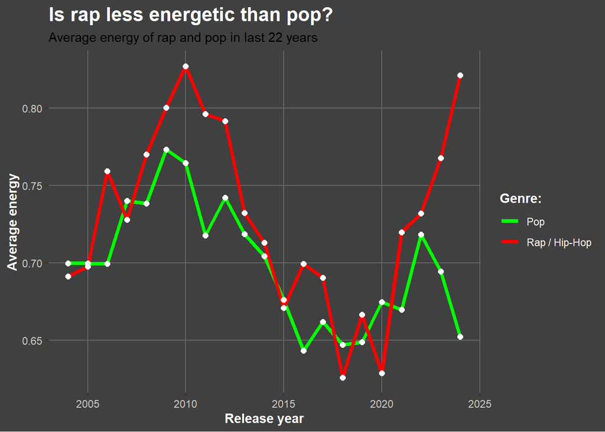

```r
genre_analysis <- music_data_v2 %>%
  filter(release_year > 2003) %>%
  mutate(
   mainstream = case_when(
     str_detect(genres, "rap|hip-hop|trap|drill") ~ "Rap / Hip-Hop",
     str_detect(genres, "pop") ~ "Pop",
     TRUE ~ "Other")
  ) %>%
  filter(mainstream != "Other")
#Above I cleared the dataset of any song from other genre than pop and hip-hop
genre_energy <- genre_analysis %>%
  group_by(release_year, mainstream) %>%
  summarise(mean_energy = mean(energy, na.rm = TRUE))


rap_pop_plot <- ggplot(data = genre_energy, aes(x = release_year, y = mean_energy, color = mainstream)) +
  geom_line(linewidth = 1.5) +
  geom_point(color = "white", size = 2) +
  scale_color_manual(values = c("Pop" = "green", "Rap / Hip-Hop" = "red")) +
  labs(
    title = "Is rap less energetic than pop?",
    subtitle = "Average energy of rap and pop in last 22 years",
    x = "Release year",
    y = "Average energy",
    color = "Genre:"
  ) +
  theme(
    plot.background = element_rect(fill = alpha("black", 0.75), color = NA),
    panel.background = element_rect(fill = "transparent", color = NA),
    axis.text = element_text(color = "gray80"),
    axis.title = element_text(color = "white", face = "bold"),
    plot.title = element_text(color = "white", face = "bold", size = 16),
    legend.background = element_rect(fill = "transparent"),
    legend.title = element_text(color = "white", face = "bold"),
    legend.text = element_text(color = "white"),
    panel.grid.major = element_line(color = "gray40"),
    panel.grid.minor = element_blank()
  )
rap_pop_plot
```

My initial hypothesis posited that the overall decline in music energy was driven by a shift in dominant genres — specifically, pop being replaced by a presumably calmer rap.

However, the data completely refuted this assumption, revealing that rap is, on average, just as energetic as pop, and often even more so.

The actual driver behind the energy drop was a global, industry-wide trend. Around 2010, artists across both genres began producing significantly calmer and more melancholic music, taking for example Adele, Billie Eilish, Travis Scott or Drake, lead artists of both genres in 2010s.That stylistic shift persisted until roughly 2020.

Last thing to do is to check if hip-hop in fact became more popular in 2010s.

### Mainstream Genre Evolution and Market Share

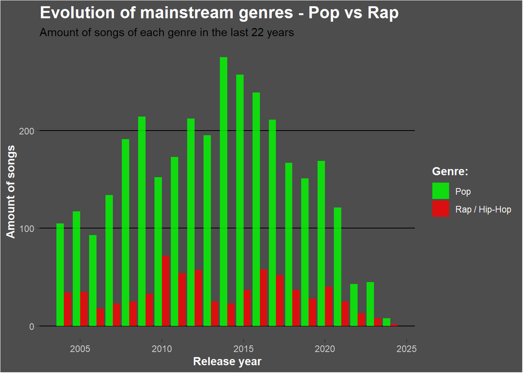

```r
genre_count <- genre_analysis %>%
  group_by(release_year, mainstream) %>%
  summarize(song_count = n(), .groups = 'drop' )

genres_plot <- ggplot(data = genre_count, aes(x = release_year, y = song_count, fill = mainstream)) +
         geom_col(position = "dodge", alpha = 0.8) +
           scale_fill_manual(values = c("Pop" = "green", "Rap / Hip-Hop" = "red")) +
           labs(
            title = "Evolution of mainstream genres - Pop vs Rap",
            subtitle = "Amount of songs of each genre in the last 22 years",
            x = "Release year",
            y = "Amount of songs",
            fill = "Genre:"
            ) +
            theme(
                plot.background = element_rect(fill = alpha("black", 0.7)),
                panel.background = element_rect(fill = "transparent"),
                axis.text = element_text(color = "gray80"),
                axis.title = element_text(color = "white", face = "bold"),
                plot.title = element_text(color = "white", face = "bold", size = 16),
                legend.background = element_rect(fill = "transparent"),
                legend.title = element_text(color = "white", face = "bold"),
                legend.text = element_text(color = "white"),
                panel.grid.major.y = element_line(color = "black"),
                panel.grid.major.x = element_blank(),
                panel.grid.minor = element_blank()
                )
genres_plot
```

Data proved partly the initial hypothesis - average count of hit hip hop songs increased in 2010s signifincantly.

Whats more interesting, in that time period, there is a negative correlation between these genres in 2010s - the more hit hip-hop songs came out, the less hit pop songs appeared.

This suggests a fierce competition for mainstream spotlight - whenever general audience was shifting towards rap it was at the cost of pop songs.

### Question 2:

How has song duration evolved across mainstream music?

### Evolution of Song Duration

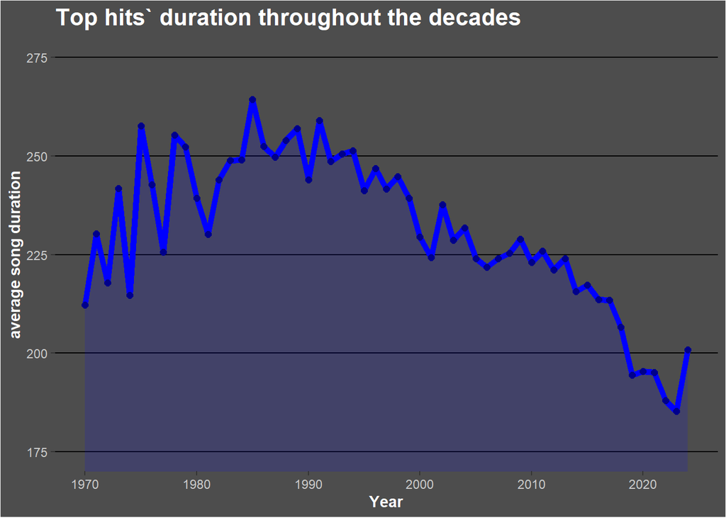

```r
music_trends_duration_v2 <- music_data_v2 %>%
  filter(release_year >=1970) %>%
  group_by(release_year) %>%
  summarise(avg_duration = mean(track_duration_s, na.rm = TRUE))

time_plot <- ggplot(data = music_trends_duration_v2, aes(x = release_year, y = avg_duration)) +
  geom_line(color = "blue", linewidth = 2 ) +
  geom_area(fill = "blue", alpha = 0.15) +
  coord_cartesian(ylim = c(175, 275)) +
  geom_point(color = "darkblue", size = 2) +
  labs(
  title = "Top hits` duration throughout the decades",
  x = "Year",
  y = "average song duration"
  ) +
  theme(
    plot.background = element_rect(fill = alpha("black", 0.7)),
    panel.background = element_rect(fill = "transparent"),
    axis.text = element_text(color = "gray80"),
    axis.title = element_text(color = "white", face = "bold"),
    plot.title = element_text(color = "white", face = "bold", size = 16),
    legend.background = element_rect(fill = "transparent"),
    legend.title = element_text(color = "white", face = "bold"),
    legend.text = element_text(color = "white"),
    panel.grid.major.y = element_line(color = "black"),
    panel.grid.major.x = element_blank(),
    panel.grid.minor = element_blank()
  )
time_plot
```

There is a downward trajectory in average song duration starting around 1990s, with extreme accelertion of that trend around 2015. This trend correlates with the rise of music streaming platforms and short form content like Tik-Tok. Shorter tracks allow for higher replayability and are more compatible with streaming algorithms, leading to a strategic shift in music production.

```r
(energy_plot + rap_pop_plot) / (genres_plot + time_plot)
ggsave("music_trends_v2.png", width = 16, height = 9, dpi = 300)
#Creating a nice conclusion image with all 4 plots
```

## 5. Conclusion and final insights

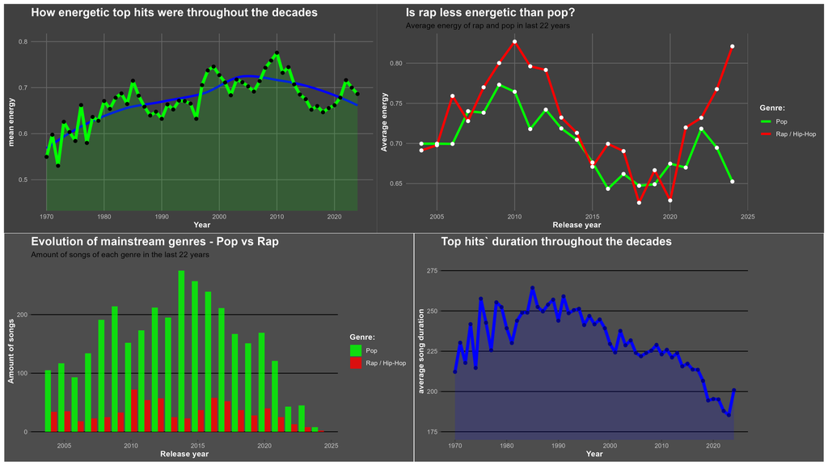

### Key Takeaways:

- Adaptability: Labels and artists should focus on music created for short form content if they want to have a higher chance of making a hit. Long songs are not recommended, preferable duration is a bit over 3 minutes.
- Trend monitoring: The inverse relationship between Pop and Rap popularity suggests that marketing strategies should be adjusted based on which genre is currently peaking.
- Adjusting the energy: Depending on the genre, nowadays Hip-Hop/Rap hits are on average way more energetic than Pop hits, which should be taken into consideration by artists, as well as lables